# Titanic Survival in Stan

James R Bland (https://sites.google.com/site/jamesbland/)

February 18, 2020

[See more posts like this here](https://sites.google.com/site/jamesbland/code-examples)

In my ECON5820 class, we spend some time learning about limited dependent variables, and regression discontinuity. One of the applications we do for both of these is to test whether the [“women and children first”](https://en.wikipedia.org/wiki/Women_and_children_first) policy had any effect on surviving the [sinking of the *Titanic*](https://en.wikipedia.org/wiki/Sinking_of_the_RMS_Titanic). A very common, but also very insightful, question that I get every year is “how do we know exactly what `child’ means?” That is, did the policy mean that people under 18 years of age were prioritized for the lifeboats (which is what we assume in class), or was it some other number?

## Data

I will be using the [Titalnic Passanger Survival Dataset](https://www.rdocumentation.org/packages/titanic/versions/0.1.0), which can be installed as an R package. If you’re not using R (which I wasn’t until about six months ago), you can download a csv of it [here](https://vincentarelbundock.github.io/Rdatasets/csv/carData/TitanicSurvival.csv). Here is what it looks like.

```r
library(titanic)
knitr::kable(head(titanic_train))
```

| PassengerId | Survived | Pclass | Name | Sex | Age | SibSp | Parch | Ticket | Fare | Cabin | Embarked |
| --- | --- | --- | --- | --- | --- | --- | --- | --- | --- | --- | --- |
| 1 | 0 | 3 | Braund, Mr. Owen Harris | male | 22 | 1 | 0 | A/5 21171 | 7.2500 |  | S |
| 2 | 1 | 1 | Cumings, Mrs. John Bradley (Florence Briggs Thayer) | female | 38 | 1 | 0 | PC 17599 | 71.2833 | C85 | C |
| 3 | 1 | 3 | Heikkinen, Miss. Laina | female | 26 | 0 | 0 | STON/O2. 3101282 | 7.9250 |  | S |
| 4 | 1 | 1 | Futrelle, Mrs. Jacques Heath (Lily May Peel) | female | 35 | 1 | 0 | 113803 | 53.1000 | C123 | S |
| 5 | 0 | 3 | Allen, Mr. William Henry | male | 35 | 0 | 0 | 373450 | 8.0500 |  | S |
| 6 | 0 | 3 | Moran, Mr. James | male | NA | 0 | 0 | 330877 | 8.4583 |  | Q |

And this is the relationship we will be trying to understand:

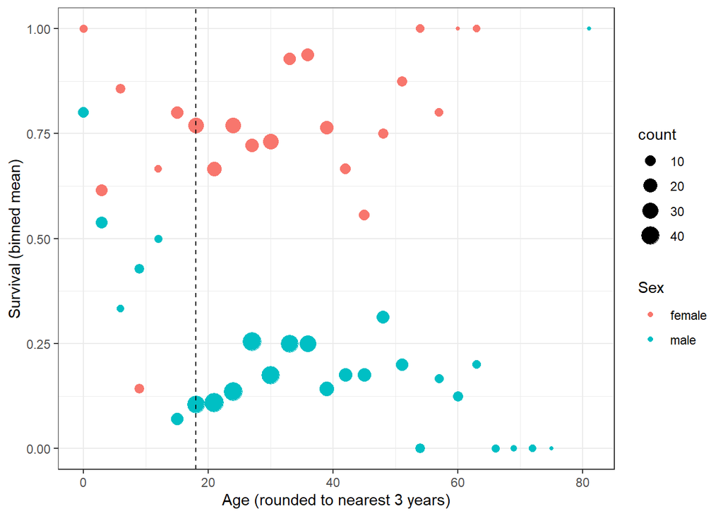

```r
D<-aggregate(titanic_train[,c("Survived")],by=list(round(titanic_train$Age/3)*3,titanic_train$Sex),FUN=mean)
colnames(D)<-c("Age","Sex","Survived")
D$count = aggregate(titanic_train[,c("Survived")],by=list(round(titanic_train$Age/3)*3,titanic_train$Sex),FUN=length)$x

plt<-ggplot(D,aes(x=Age,y=Survived,color=Sex,size=count))+geom_point()+theme_bw()
plt<-plt+xlab("Age (rounded to nearest 3 years)")+ylab("Survival (binned mean)")
plt<-plt+geom_vline(xintercept=18,linetype="dashed",color="black")
plt
```

Here I plot binned means (age rounded to the nearest 3 years) of male and female passages.

## Regression Discontinuity Design

I will be estimating, for male passengers, the effect of being a child on survival using Regression Discontinuity Design (RDD). If you are unfamiliar with this, or need a refresher, see the chapter on Scott Cunningham’s [“Causal Inference: The Mixtape”](https://www.scunning.com/mixtape.html). The basic RDD model takes advantage of a strict cut-off rule for treatment assignment (i.e. being classified as a child). To begin with, let’s assume that we know that this cut-off is 18 years. I.e. Passengers who are under 18 years old are given preference on the life boats compared to those over 18 years old. RDD in this case assumes that passengers who are 17.99 years old serve as a very good counter-factual to what would have happened to an 18.01 year-old, and attributes the difference to this policy. As the independent variable is binary, I will be estimating a logit:
$$\mathrm{logit}\Pr[\mathrm{Survived}_i \mid \mathrm{age}_i, Z_i]= \beta_0 I(\mathrm{age}>18)
+\sum_{k=1}^P\left[\beta_{2k-1}(\mathrm{age}_i-18)^k+\beta_{2k}I(\mathrm{age}>18)(\mathrm{age}_i-18)^k\right]+W Z_i$$
Where $Z_i$ is a set of control variables (the variable PClass), and $\sum_{k=1}^P\left[\beta_{2k-1}(\mathrm{age}_i-18)^k+\beta_{2k}I(\mathrm{age}>18)(\mathrm{age}_i-18)^k\right]$ smooths out the relationship between age and survival for ages not at the cutoff with a $P$th order polynomial (I’m setting $P=1$). I will just use the data for men who are 30 years or younger, because it is unlikely that (say) the 80-year-olds will tell us much about the children.

Here is my program to do this in Stan:

```c
data {
  int<lower=0> N; // Sample size
  int<lower=0> P; // Polynomial for assignment variable
  int<lower=0,upper=1> y[N]; // outcome (1/0)
  vector[N] assignment; // assignment variable
  int<lower=1> kZ; // number of control variables
  matrix[N,kZ] Z; // control variables
  vector[kZ] priorZ; // prior for control variables (mean zero, specify sd of normal)
  vector[2*P+1] priorXsd; // prior for polynomial and cutoff (sd)
  vector[2*P+1] priorXm; // prior for polynomial and cutoff (mean)
  real cut; // value of the cutoff
}
transformed data {
    vector[N] aboveCut;
    matrix[N,2*P+1] X;
    for (ii in 1:N) {
        aboveCut[ii] = step(assignment[ii]-cut);
        }
for (ii in 1:N){
    X[ii,1] = aboveCut[ii];
    for (pp in 1:P) {
        X[ii,2*pp] = (assignment[ii]-cut)^pp;
        X[ii,2*pp+1] = aboveCut[ii].*(assignment[ii]-cut)^pp;
        }
}
}
parameters {
  vector[2*P+1] beta;

  vector[kZ] W;

}
model {
  W ~ normal(0,priorZ);
  beta ~ normal(priorXm,priorXsd);
  y ~ bernoulli_logit(X*beta + Z*W);
}
```

which produced the following output:

```r
Fit<-readRDS("TitanicRD.rds")
knitr::kable(summary(Fit)$summary)
```

|  | mean | se_mean | sd | 2.5% | 25% | 50% | 75% | 97.5% | n_eff | Rhat |
| --- | --- | --- | --- | --- | --- | --- | --- | --- | --- | --- |
| beta[1] | -0.7891503 | 0.0046768 | 0.2555679 | -1.2882564 | -0.9594216 | -0.7906582 | -0.6182441 | -0.2890728 | 2986.172 | 1.0015295 |
| beta[2] | -0.0942615 | 0.0005823 | 0.0306529 | -0.1557792 | -0.1149279 | -0.0943880 | -0.0730790 | -0.0348922 | 2770.836 | 0.9998928 |
| beta[3] | 0.1123856 | 0.0010840 | 0.0568061 | -0.0006376 | 0.0734755 | 0.1128052 | 0.1516209 | 0.2197756 | 2746.400 | 0.9997638 |
| W[1] | -0.5008630 | 0.0043354 | 0.2409724 | -0.9716750 | -0.6625722 | -0.4996409 | -0.3329622 | -0.0352121 | 3089.448 | 0.9993321 |
| W[2] | -0.3539324 | 0.0043585 | 0.2438654 | -0.8356168 | -0.5198979 | -0.3530654 | -0.1833820 | 0.1081996 | 3130.632 | 1.0000469 |
| W[3] | -0.6427589 | 0.0039673 | 0.2174543 | -1.0559847 | -0.7880899 | -0.6431578 | -0.5023310 | -0.2080527 | 3004.297 | 0.9993806 |
| lp__ | -118.8253794 | 0.0423986 | 1.7905778 | -123.3121994 | -119.7157347 | -118.4784321 | -117.5346452 | -116.4046640 | 1783.546 | 0.9996459 |

“beta[1]” is the coefficient of interest (i.e. $\beta_0$ above). Clearly it shows that over-18 males were less likely to survive than those under 18, but what is the extent of this? A more useful quantity to report is the odds ratio:
$$\lim_{\epsilon\to0^+}\left[\frac{p(\mathrm{survived}\mid \mathrm{age}_i=18+\epsilon)}{1-p(\mathrm{survived}\mid \mathrm{age}_i=18+\epsilon)} \frac{1-p(\mathrm{survived}\mid \mathrm{age}_i=18-\epsilon)}{p(\mathrm{survived}\mid \mathrm{age}_i=18-\epsilon)}\right]=\frac{\exp(\beta_0+WZ_i)}{\exp(WZ_i)}=\exp(\beta_0)$$

which we can extract from the Stan fit object quite easily as:

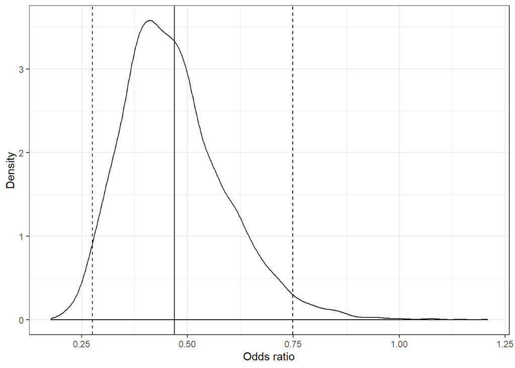

```r
b0 <-  extract(Fit,pars="beta[1]")$`beta[1]`
Ratio<-exp(b0)
d<-data.frame(Ratio)
ggplot(data=d,aes(x=Ratio))+geom_density()+theme_bw()+xlab("Odds ratio")+ylab("Density")+geom_vline(xintercept=mean(d$Ratio),color="black")+geom_vline(xintercept=quantile(d$Ratio,c(0.025,0.975)),linetype="dashed",color="black")
```

```r
mean(d$Ratio)
```

```
## [1] 0.4693797
```

So male adults had about half the odds of surviving than did male children.

## Is 18 really the right number?

How can we be sure that 18 is actually the right cutoff for the definition of a child? (I waive my hands at the follow-up question “do we even know if there *is* a cutoff?”). I get asked this question a lot in class, so here is my attempt at answering it. Instead of having the cutoff be an input into the model, let’s make it a parameter and estimate it:

```c
data {
  int<lower=0> N; // Sample size
  int<lower=0> P; // Polynomial for assignment variable
  int<lower=0,upper=1> y[N]; // outcome (1/0)
  vector[N] assignment; // assignment variable
  int<lower=1> kZ; // number of control variables
  matrix[N,kZ] Z; // control variables
  vector[kZ] priorZ; // prior for control variables (mean zero, specify sd of normal)
  vector[2*P+1] priorXsd; // prior for polynomial and cutoff (sd)
  vector[2*P+1] priorXm; // prior for polynomial and cutoff (mean)
  vector[2] CutPrior; // Prior for cutoff

}
transformed data {

}
parameters {
  vector[2*P+1] beta;

  real cut;

  vector[kZ] W;

}
model {

    vector[N] aboveCut;
    matrix[N,2*P+1] X;
    for (ii in 1:N) {
        aboveCut[ii] = step(assignment[ii]-cut);
        }
    for (ii in 1:N){
    X[ii,1] = aboveCut[ii];
        for (pp in 1:P) {
            X[ii,2*pp] = (assignment[ii]-cut)^pp;
            X[ii,2*pp+1] = aboveCut[ii].*(assignment[ii]-cut)^pp;
        }
    }


  cut ~ normal(CutPrior[1],CutPrior[2]);
  W ~ normal(0,priorZ);
  beta ~ normal(priorXm,priorXsd);
  y ~ bernoulli_logit(X*beta + Z*W);
}
```

which produced the following output:

```r
Fit2<-readRDS("TitanicRDUncertainCutoff.rds")
knitr::kable(summary(Fit2)$summary)
```

|  | mean | se_mean | sd | 2.5% | 25% | 50% | 75% | 97.5% | n_eff | Rhat |
| --- | --- | --- | --- | --- | --- | --- | --- | --- | --- | --- |
| beta[1] | -0.8662914 | 0.0120417 | 0.2621619 | -1.3703750 | -1.0414630 | -0.8665377 | -0.6873507 | -0.3445378 | 473.9812 | 1.003434 |
| beta[2] | -0.1126364 | 0.0022199 | 0.0407188 | -0.1954542 | -0.1395307 | -0.1119675 | -0.0852114 | -0.0345862 | 336.4406 | 1.009845 |
| beta[3] | 0.1085277 | 0.0032368 | 0.0582146 | -0.0078189 | 0.0688674 | 0.1090140 | 0.1478299 | 0.2217573 | 323.4772 | 1.007849 |
| cut | 14.2851245 | 0.0798100 | 1.6607421 | 10.8775607 | 13.1911955 | 14.2595663 | 15.4612715 | 17.4766100 | 433.0015 | 1.006775 |
| W[1] | -0.3234660 | 0.0141715 | 0.2535075 | -0.8306412 | -0.4932104 | -0.3278004 | -0.1591959 | 0.1780038 | 320.0008 | 1.008307 |
| W[2] | -0.3423872 | 0.0114575 | 0.2463434 | -0.8269085 | -0.5055248 | -0.3417245 | -0.1780111 | 0.1405788 | 462.2742 | 1.007058 |
| W[3] | -0.5477605 | 0.0092890 | 0.2211845 | -1.0009527 | -0.6919351 | -0.5508076 | -0.4021203 | -0.1090467 | 566.9805 | 1.001792 |
| lp__ | -117.4692532 | 0.0557824 | 1.7789995 | -121.6346379 | -118.5001927 | -117.1910925 | -116.1432064 | -114.8829875 | 1017.0843 | 1.003325 |

So it seems more likely that if there *was* a cutoff, it was more likely to be in the 14-15 range than 18:

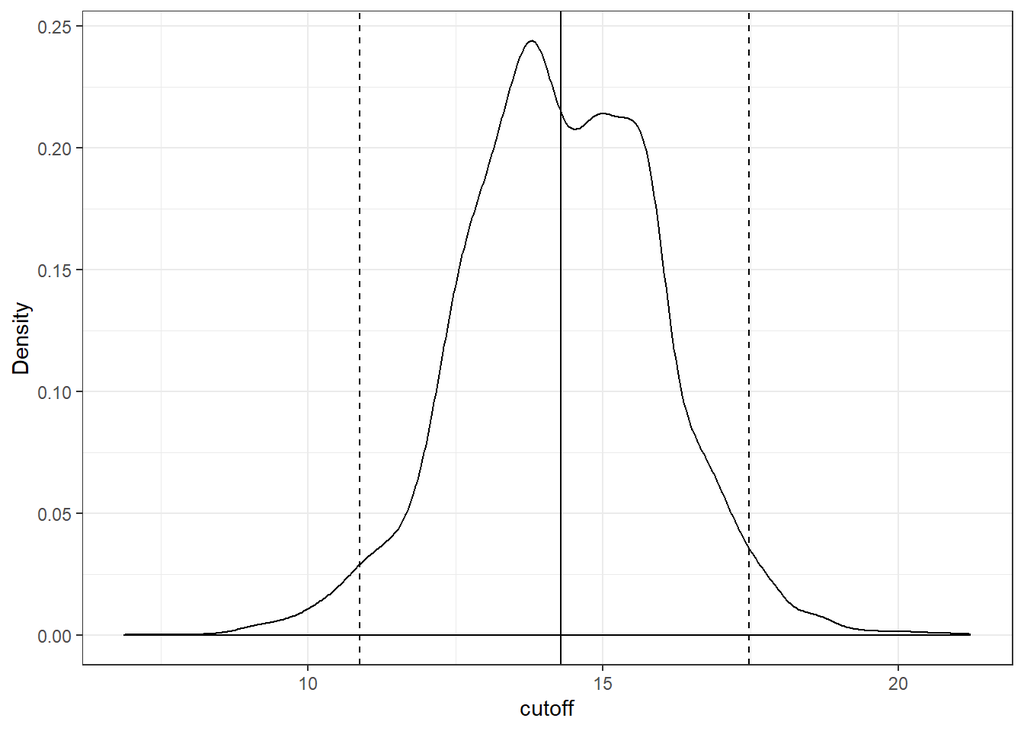

```r
cutoff <-  extract(Fit2,pars="cut")$cut

d<-data.frame(cutoff)
ggplot(data=d,aes(x=cutoff))+geom_density()+theme_bw()+ylab("Density")+geom_vline(xintercept=mean(d$cutoff),color="black")+geom_vline(xintercept=quantile(d$cutoff,c(0.025,0.975)),linetype="dashed",color="black")
```

And now we can use this model to express our uncertainty about the cutoff in the odds ratio:

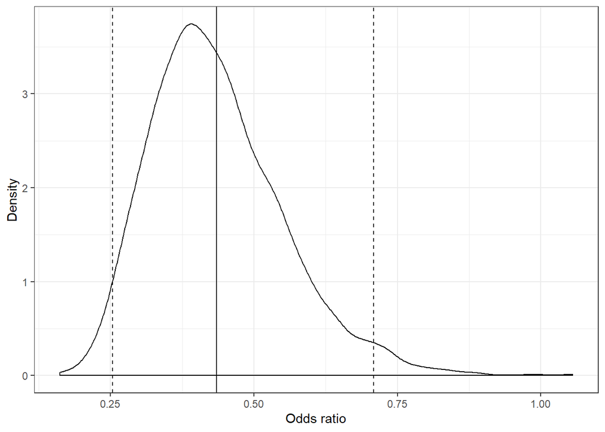

```r
b0 <-  extract(Fit2,pars="beta[1]")$`beta[1]`
Ratio<-exp(b0)
d<-data.frame(Ratio)
ggplot(data=d,aes(x=Ratio))+geom_density()+theme_bw()+xlab("Odds ratio")+ylab("Density")+geom_vline(xintercept=mean(d$Ratio),color="black")+geom_vline(xintercept=quantile(d$Ratio,c(0.025,0.975)),linetype="dashed",color="black")
```

```r
mean(d$Ratio)
```

```
## [1] 0.4351994
```

Which didn’t really change our answer that much.

## Comparing the models

Finally, I plot the predictions of the two models, as well as the data (binned means for males), on the same graph. Ribbons around the lines show a 95% Bayesian credible region around the mean prediction (2.5th to 97.5th percentiles).

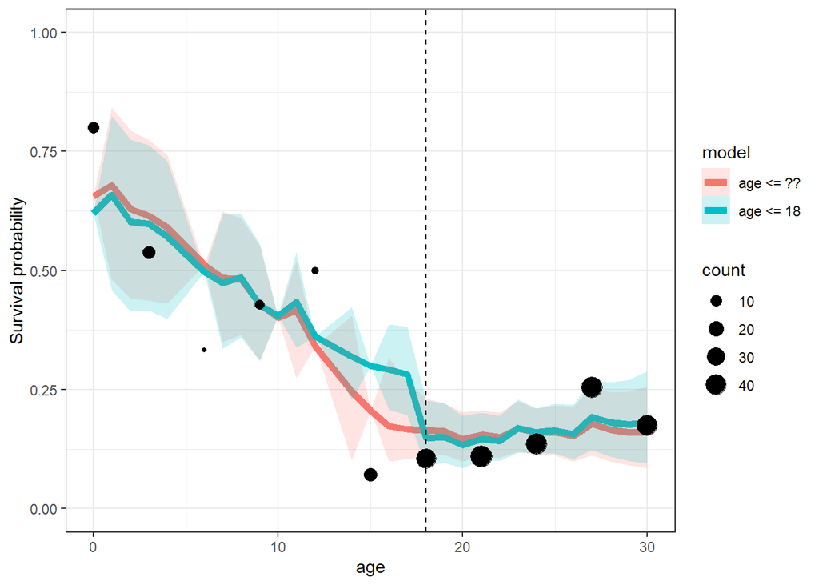

```r
Predictions<-readRDS("TitanicPredictions.rds")
plt<-ggplot(data=Predictions[Predictions$UAssignment<=30,],aes(x=UAssignment,y=m))+geom_line(size=2,aes(color=model))
plt<-plt+geom_ribbon(alpha=0.2,size=0,aes(ymin=lb,ymax=ub,fill=model))
plt<-plt+geom_point(data=D[D$Sex=="male" & D$Age<=30,],aes(x=Age,y=Survived,size=count))
plt<-plt+theme_bw()+xlab("age")+ylab("Survival probability")
plt<-plt+geom_vline(xintercept=18,linetype="dashed",color="black")+ylim(0,1)
plt
```

The prediction marginalizes over the covariates $Z$ for each age (this is really just class), so most of the noise associated with these curves, apart from parameter uncertainty, comes from there being different class compositions at each age. The standard model (blue line) unsurprisingly has a sharp drop in survival probability at age 18. However the uncertain cutoff model (red line) dips more gradually because we don’t have a clear idea about where the cutoff is.

[See more posts like this here](https://sites.google.com/site/jamesbland/code-examples)

## Appendix: R code

```r
library(ggplot2)
library(gganimate)

library("rstan") # observe startup messages
rstan_options(auto_write = TRUE)
Sys.setenv(LOCAL_CPPFLAGS = '-march=native')
options(mc.cores = parallel::detectCores())

rm(list=ls())
library(titanic)
library(boot)

D<-aggregate(titanic_train[,c("Survived")],by=list(round(titanic_train$Age/3)*3,titanic_train$Sex),FUN=mean)
colnames(D)<-c("Age","Sex","Survived")
D$count = aggregate(titanic_train[,c("Survived")],by=list(round(titanic_train$Age/3)*3,titanic_train$Sex),FUN=length)$x


plt<-ggplot(D,aes(x=Age,y=Survived,color=Sex,size=count))+geom_point()+theme_bw()
plt<-plt+xlab("Age (rounded to nearest 3 years)")+ylab("Survival (binned mean)")
plt<-plt+geom_vline(xintercept=18,linetype="dashed",color="black")
plt

Data<-titanic_train[is.na(titanic_train$Age)==FALSE & titanic_train$Sex=="male" & titanic_train$Age<=30,]


assignment <-Data$Age
cut<-18

Z<-as.matrix(cbind(matrix(1,dim(Data)[1],1),as.numeric(Data$Pclass==2),as.numeric(Data$Pclass==3)))

P = 1

priorZ<-as.vector(matrix(0.3,dim(Z)[2]))
priorXsd<-as.vector(matrix(0.3,2*P+1))
priorXm<-c(-0.6,0,0)

d<-list(N=length(assignment),assignment=assignment,cut=cut,P=P,y=as.vector(Data$Survived),Z=Z,kZ=dim(Z)[2],priorZ=priorZ,priorXm=priorXm,priorXsd=priorXsd)

Fit<-stan('logitRD.stan',data=d,seed=42)
Fit
saveRDS(Fit,"TitanicRD.rds")

d<-list(N=length(assignment),assignment=assignment,CutPrior=c(18,3),P=P,y=as.vector(Data$Survived),Z=Z,kZ=dim(Z)[2],priorZ=priorZ,priorXm=priorXm,priorXsd=priorXsd)

Fit2<-stan('logitRDUncertainCutoff.stan',data=d,seed=42)
Fit2
saveRDS(Fit2,"TitanicRDUncertainCutoff.rds")

## predictions
EFit<-extract(Fit)
BETA<-EFit$beta
W<-EFit$W

X<-cbind(as.matrix((assignment>=cut)),as.matrix(assignment-cut),as.matrix((assignment-cut)*(assignment>=cut)))

predictions<-inv.logit(t(BETA %*% t(X) + W %*% t(Z)))
UAssignment = sort(unique(round(assignment)))
m<-rep(0,length(UAssignment))
lb<-rep(0,length(UAssignment))
ub<-rep(0,length(UAssignment))

for (aa in 1:length(UAssignment)) {
  II <- abs(assignment-UAssignment[aa])<=0.5

    s<-colMeans(as.matrix(predictions[II,]))

  m[aa] = mean(s)
  lb[aa]<-quantile(s,0.025)
  ub[aa]<-quantile(s,0.975)
}
PREDICTIONS<-data.frame(UAssignment,m,lb,ub)
PREDICTIONS$model<-"age <= 18"

#
EFit2<-extract(Fit2)
BETA<-EFit2$beta
W<-EFit2$W
CUT<-EFit2$cut
m<-rep(0,length(UAssignment))
lb<-rep(0,length(UAssignment))
ub<-rep(0,length(UAssignment))


INDEX = t( W %*% t(Z))
for (ss in 1:length(CUT)) {
  X<-cbind(as.matrix((assignment>=CUT[ss])),as.matrix(assignment-CUT[ss]),as.matrix((assignment-CUT[ss])*(assignment>=CUT[ss])))
  INDEX[,ss]<-INDEX[,ss]+BETA[ss,] %*% t(X)
}
predictions<-inv.logit(INDEX)

m<-rep(0,length(UAssignment))
lb<-rep(0,length(UAssignment))
ub<-rep(0,length(UAssignment))

for (aa in 1:length(UAssignment)) {
  II <- abs(assignment-UAssignment[aa])<=0.5
  s<-colMeans(as.matrix(predictions[II,]))
  m[aa] = mean(s)
  lb[aa]<-quantile(s,0.025)
  ub[aa]<-quantile(s,0.975)
}
tmp<-data.frame(UAssignment,m,lb,ub)
tmp$model<-"age <= ??"
PREDICTIONS<-rbind(PREDICTIONS,tmp)
saveRDS(PREDICTIONS,"TitanicPredictions.rds")
```

[See more posts like this here](https://sites.google.com/site/jamesbland/code-examples)